# Gizem Ates 121516052

# SORU 1

**Kaynak:** https://www.kaggle.com/nareshbhat/wine-quality-binary-classification

**Aciklama** Bu Veri seti, kirmizi sarap icin kaliteyi etkileyen cesitli faktorler ile ilgili bilgileri içerir.

**Degiskenler**

**quality** bad , good

**fixed acidity** sabit asitlik degeri

**volatile acidity** uçucu asitlik degeri

**citric acid** sitrik asit degeri

**residual sugar** artik seker

**chlorides** klorur degeri degeri

**free sulfur dioxide** serbest kukurt dioksit degeri

**total sulfur dioxide** toplam kukurt dioksit degeri

**density** yogunluk

**pH** pH degeri

**sulphates** sulfat degeri

**alcohol** alkol degeri

```r
veri <- read.csv("C:/Users/gizem/OneDrive/Masaüstü/wine.csv")
```

```r
head(veri)
```

```
  fixed.acidity volatile.acidity citric.acid residual.sugar chlorides
1           7.4             0.70        0.00            1.9     0.076
2           7.8             0.88        0.00            2.6     0.098
3           7.8             0.76        0.04            2.3     0.092
4          11.2             0.28        0.56            1.9     0.075
5           7.4             0.70        0.00            1.9     0.076
6           7.4             0.66        0.00            1.8     0.075
  free.sulfur.dioxide total.sulfur.dioxide density   pH sulphates alcohol
1                  11                   34  0.9978 3.51      0.56     9.4
2                  25                   67  0.9968 3.20      0.68     9.8
3                  15                   54  0.9970 3.26      0.65     9.8
4                  17                   60  0.9980 3.16      0.58     9.8
5                  11                   34  0.9978 3.51      0.56     9.4
6                  13                   40  0.9978 3.51      0.56     9.4
  quality
1     bad
2     bad
3     bad
4    good
5     bad
6     bad
```

```r
summary(veri)
```

```
 fixed.acidity   volatile.acidity  citric.acid    residual.sugar
 Min.   : 4.60   Min.   :0.1200   Min.   :0.000   Min.   : 0.900
 1st Qu.: 7.10   1st Qu.:0.3900   1st Qu.:0.090   1st Qu.: 1.900
 Median : 7.90   Median :0.5200   Median :0.260   Median : 2.200
 Mean   : 8.32   Mean   :0.5278   Mean   :0.271   Mean   : 2.539
 3rd Qu.: 9.20   3rd Qu.:0.6400   3rd Qu.:0.420   3rd Qu.: 2.600
 Max.   :15.90   Max.   :1.5800   Max.   :1.000   Max.   :15.500
   chlorides       free.sulfur.dioxide total.sulfur.dioxide    density
 Min.   :0.01200   Min.   : 1.00       Min.   :  6.00       Min.   :0.9901
 1st Qu.:0.07000   1st Qu.: 7.00       1st Qu.: 22.00       1st Qu.:0.9956
 Median :0.07900   Median :14.00       Median : 38.00       Median :0.9968
 Mean   :0.08747   Mean   :15.87       Mean   : 46.47       Mean   :0.9967
 3rd Qu.:0.09000   3rd Qu.:21.00       3rd Qu.: 62.00       3rd Qu.:0.9978
 Max.   :0.61100   Max.   :72.00       Max.   :289.00       Max.   :1.0037
       pH          sulphates         alcohol        quality
 Min.   :2.740   Min.   :0.3300   Min.   : 8.40   Length:1599
 1st Qu.:3.210   1st Qu.:0.5500   1st Qu.: 9.50   Class :character
 Median :3.310   Median :0.6200   Median :10.20   Mode  :character
 Mean   :3.311   Mean   :0.6581   Mean   :10.42
 3rd Qu.:3.400   3rd Qu.:0.7300   3rd Qu.:11.10
 Max.   :4.010   Max.   :2.0000   Max.   :14.90
```

```r
veri$quality<-as.factor(veri$quality)
```

**Verimizi cektik. Bagimli degiskenimizi faktore donusturduk. Eksik gozlem kontrolu yapalim.**

```r
apply(veri,2,function(x) sum(is.na(x)))
```

```
       fixed.acidity     volatile.acidity          citric.acid
                   0                    0                    0
      residual.sugar            chlorides  free.sulfur.dioxide
                   0                    0                    0
total.sulfur.dioxide              density                   pH
                   0                    0                    0
           sulphates              alcohol              quality
                   0                    0                    0
```

**Veride eksik gozlem bulunmamaktadir. Simdi degiskenlerimizin aralarindaki iliskiyi inceleyelim.**

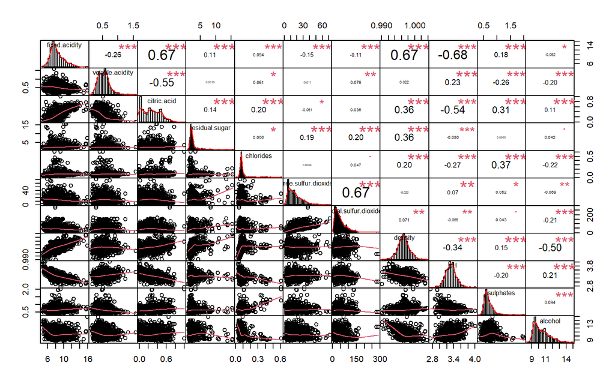

**Bazi degiskenlerin arasinda iliskiler var gibi gozukuyor ama genel cok anlamli iliskilerin oldugu soylenemez.**

```r
set.seed(123)
index <- sample(1:nrow(veri),round(0.80*nrow(veri)))
train <- veri[index,]
test <- veri[-index,]
```

**%80 train , %20 test veri seti olacak sekilde ayarlandi.*

## Decision Trees

```r
library(tree)
library(ISLR)
set.seed(34562)
tree.model1=tree(quality~., data=train)
summary(tree.model1)
```

```
Classification tree:
tree(formula = quality ~ ., data = train)
Variables actually used in tree construction:
[1] "alcohol"              "total.sulfur.dioxide" "sulphates"
[4] "volatile.acidity"     "pH"
Number of terminal nodes:  9
Residual mean deviance:  1.014 = 1287 / 1270
Misclassification error rate: 0.2385 = 305 / 1279
```

**Modelimizi kurduk. Kullanilan dal sayisini ve hata metriklerimizi goruyoruz. Simdi agacin yapisini inceleyelim**

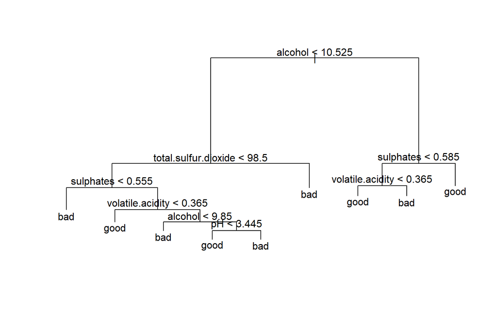

```r
plot(tree.model1)
text(tree.model1,pretty=0)
```

**Agacimiz duzenli ve anlasilir gozukuyor. Test verisi uzerinde basari oranimizi hesaplamaya gecebiliriz.**

```r
set.seed(234)
tahmin=predict(tree.model1, test, type="class")
```

```r
set.seed(234)
table(tahmin,test$quality)
```

```
tahmin bad good
  bad  120   52
  good  40  108
```

**Tablomuzu olusturduk. Accuracy, Sensitivity ve Specificity oranimizi hesaplamaya gecelim.**

```r
set.seed(234)
sensitivity(table(tahmin,test$quality))
```

```
[1] 0.75
```

```r
specificity(table(tahmin,test$quality))
```

```
[1] 0.675
```

```r
set.seed(234)
TahminPerf=data.frame(Accuracy=(120+108)/320,Sensitivity=0.75,specificity=0.675)
TahminPerf
```

```
  Accuracy Sensitivity specificity
1   0.7125        0.75       0.675
```

**Accuracy degerimiz %71.25 geldi. Iyi bir deger oldugu soylenemez. Simdi yapacagimiz is olusturdugumuz agaci budamanin dogru olup olmayacagina bakmak.**

## Pruning

```r
set.seed(14543)
tree.model2=cv.tree(tree.model1, FUN=prune.misclass)
tree.model2
```

```
$size
[1] 9 7 6 2 1

$dev
[1] 373 373 408 408 547

$k
[1]   -Inf   1.00  16.00  16.75 194.00

$method
[1] "misclass"

attr(,"class")
[1] "prune"         "tree.sequence"
```

**Cross-Validation ile deviance ve size degerlerine bakiyoruz. Size=9 ve Size=7 aynı degerlere sahip. Simdi bunu gorselle inceleyelim.**

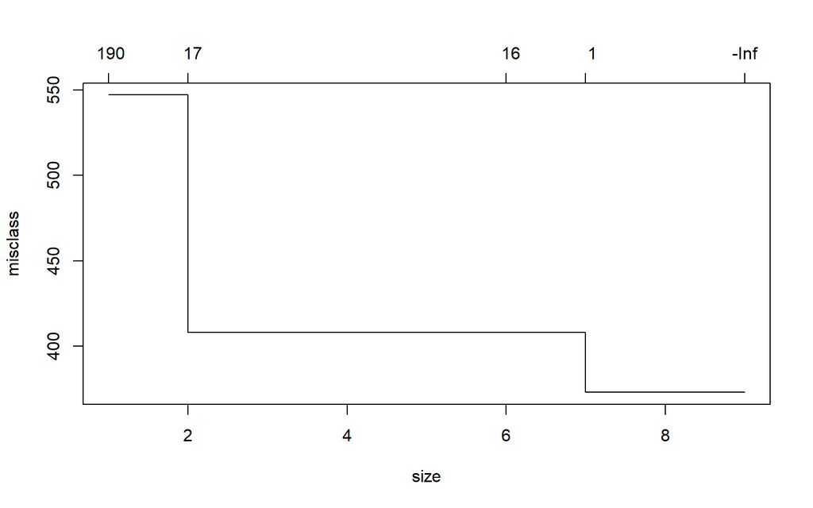

```r
plot(tree.model2)
```

**Goruldugu uzere 7, 8 ve 9 ayni sonuclari veriyor. Buna bakip dogru karari verelim.**

```r
set.seed(123)
tree.model2=prune.misclass(tree.model1,best=7)
summary(tree.model2)
```

```
Classification tree:
snip.tree(tree = tree.model1, nodes = 3L)
Variables actually used in tree construction:
[1] "alcohol"              "total.sulfur.dioxide" "sulphates"
[4] "volatile.acidity"     "pH"
Number of terminal nodes:  7
Residual mean deviance:  1.069 = 1360 / 1272
Misclassification error rate: 0.24 = 307 / 1279
```

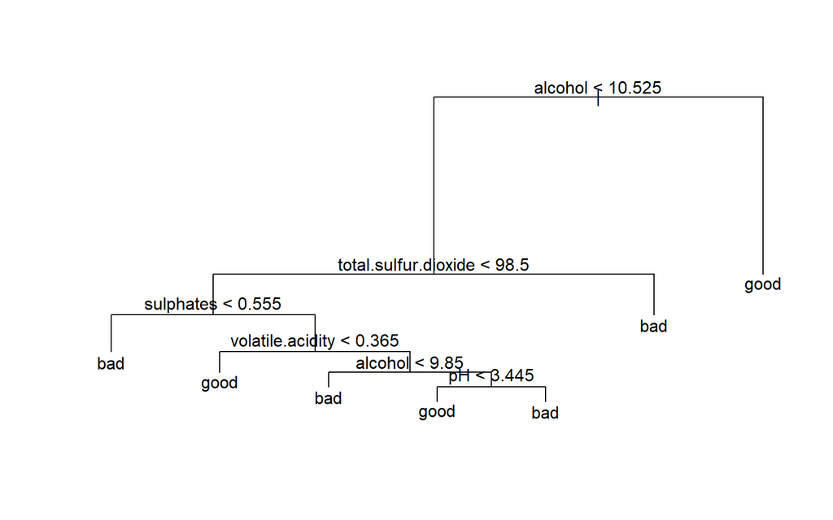

```r
plot(tree.model2)
text(tree.model2,pretty=0)
```

**Klasik karar agacimizdaa gore cok buyuk farkliliklar gostermedi.**

**7 node ile modelimizi kurduk. Bakalim test verisi uzerindeki performasi nasil olacak?**

```r
set.seed(234)
tahmin=predict(tree.model2,test,type="class")
```

```r
set.seed(234)
table(tahmin,test$quality)
```

```
tahmin bad good
  bad  109   44
  good  51  116
```

**Tablomuzu olusturduk. Accuracy, Sensitivity ve Specificity oranimizi hesaplamaya gecelim.**

```r
set.seed(234)
sensitivity(table(tahmin,test$quality))
```

```
[1] 0.68125
```

```r
specificity(table(tahmin,test$quality))
```

```
[1] 0.725
```

```r
set.seed(234)
TahminPerf=data.frame(Accuracy=(109+116)/320,Sensitivity=0.68125,specificity=0.725)
TahminPerf
```

```
  Accuracy Sensitivity specificity
1 0.703125     0.68125       0.725
```

**Tahmin performansimizda dusus yasandi. Budama islemine ihtiyacimiz yok. Bunu gormus olduk.**

## Bagging

### 500 Bootstrap Sample

```r
library(randomForest)
set.seed(12345)
Bagging.model1=randomForest(quality~., data=train, mtry=12, importance=TRUE)
Bagging.model1
```

```
Call:
 randomForest(formula = quality ~ ., data = train, mtry = 12,      importance = TRUE)
               Type of random forest: classification
                     Number of trees: 500
No. of variables tried at each split: 11

        OOB estimate of  error rate: 19.31%
Confusion matrix:
     bad good class.error
bad  465  119   0.2037671
good 128  567   0.1841727
```

**Bagging modelimizi kurduk. Tum degiskenler kullanildi. Amacimiz yuksek varyans sorununu olabildigince dusurmek. Default olarak 500 agac kullanildi ve out of bag error degerimiz verildi. Simdi degiskenlerimizin onemliliklerine goz atacagiz.**

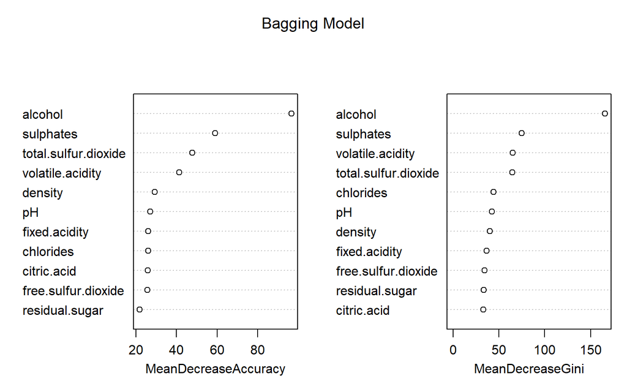

```r
varImpPlot(Bagging.model1, main = "Bagging Model")
```

**Goruldugu uzere Alcohol degiskeni her iki olcut icinde oldukca onemli. Hadi test uzerindeki performasimiza bakalim.**

```r
library( e1071)
library(caret)
set.seed(333)
tahmin = predict(Bagging.model1,newdata=test)
```

```r
table(tahmin,test$quality)
```

```
tahmin bad good
  bad  131   27
  good  29  133
```

**Tablomuzu olusturduk. Accuracy, Sensitivity ve Specificity oranimizi hesaplamaya gecelim.**

```r
sensitivity(table(tahmin,test$quality))
```

```
[1] 0.81875
```

```r
specificity(table(tahmin,test$quality))
```

```
[1] 0.83125
```

```r
TahminPerf=data.frame(Accuracy=(131+133)/320,Sensitivity=0.81875,Specificity=0.83125)
TahminPerf
```

```
  Accuracy Sensitivity Specificity
1    0.825     0.81875     0.83125
```

**Accuracy degerimiz %82.5 geldi. 500 agac ile kurdugumuz model ile Klasik karar agacina gore cok daha iyi bir deger elde ettigimizi soyleyebiliriz. Simdi ise 500 agac sayisini dusurebilir miyiz ona bakacagiz.**

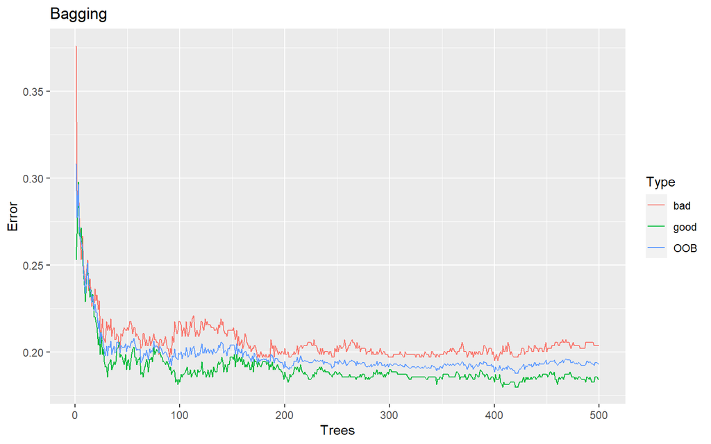

**Grafikte goruldugu gibi 500 ile degil de daha az agac sayisi ile (ornegin 100) calisirsak accuracy degerimizde cok bir fark olmayacaktir. Ancak deneyip oyle gorecegiz.**

### 100 Bootstrap Sample

```r
library(randomForest)
set.seed(1425)
Bagging.model1=randomForest(quality~., data=train, mtry=12, ntree=100, importance=TRUE)
Bagging.model1
```

```
Call:
 randomForest(formula = quality ~ ., data = train, mtry = 12,      ntree = 100, importance = TRUE)
               Type of random forest: classification
                     Number of trees: 100
No. of variables tried at each split: 11

        OOB estimate of  error rate: 19.94%
Confusion matrix:
     bad good class.error
bad  457  127   0.2174658
good 128  567   0.1841727
```

```r
table(tahmin,test$quality)
```

[output not shown]

**Tablomuzu olusturduk. Accuracy, Sensitivity ve Specificity oranimizi hesaplamaya gecelim.**

```r
sensitivity(table(tahmin,test$quality))
```

```
[1] 0.8375
```

```r
specificity(table(tahmin,test$quality))
```

```
[1] 0.825
```

```r
TahminPerf=data.frame(Accuracy=(134+132)/320,Sensitivity=0.8375,Specificity=0.825)
TahminPerf
```

```
  Accuracy Sensitivity Specificity
1  0.83125      0.8375       0.825
```

**Goruldugu gibi 100 Boostrap sample ile kurdugumuz model hem daha basarili oldu hem de bizi is yukunden kurtarmis oldu.**

## Random Forest

**Bagging yaptik. Simdi mtray degerini degisken sayimizin kok degerini alip randomforest yapalim.**

**Amacimiz kuvvetli degiskenlerin baggingde tekrar etmesini durdurmak. Varyansın dusmemesine neden olur. Bu durumda Random Forest, Bagging agaclarinda ilişkisizligi saglayarak varyansta dususe yardimci olabilir.**

```r
library(randomForest)
set.seed(12345)
Randomforest.model1=randomForest(quality~., data=train, mtry=4, importance=TRUE)
Randomforest.model1
```

```
Call:
 randomForest(formula = quality ~ ., data = train, mtry = 4, importance = TRUE)
               Type of random forest: classification
                     Number of trees: 500
No. of variables tried at each split: 4

        OOB estimate of  error rate: 18.61%
Confusion matrix:
     bad good class.error
bad  465  119   0.2037671
good 119  576   0.1712230
```

**mtry=4 ile modelimizi kurduk. Degiskenlerin onemlilik derecelerine baktiktan sonra test verisi uzerindeki performansimizi inceleyecegiz.**

[figure not shown]

```r
library(e1071)
tahmin = predict(Randomforest.model1,newdata=test)
```

```r
table(tahmin,test$quality)
```

```
tahmin bad good
  bad  127   30
  good  33  130
```

**Tablomuzu olusturduk. Accuracy, Sensitivity ve Specificity oranimizi hesaplamaya gecelim.**

```r
sensitivity(table(tahmin,test$quality))
```

```
[1] 0.79375
```

```r
specificity(table(tahmin,test$quality))
```

```
[1] 0.8125
```

```r
TahminPerf=data.frame(Accuracy=(127+130)/320,Sensitivity=0.79375,Specificity=0.8125)
TahminPerf
```

```
  Accuracy Sensitivity Specificity
1 0.803125     0.79375      0.8125
```

**Accuracy degerimiz %80.3 geldi. Yolumuza Boosting ile devam edelim.**

## Boosting

**Boosting daha kucuk agaclar kullanir ve o agactan edinilen bilgiler digerine gonderilir. Yavas ogrenme olur. Iteratif bir yapiya sahip olan bu metod bakalim bize nasil sonuclar verecek.**

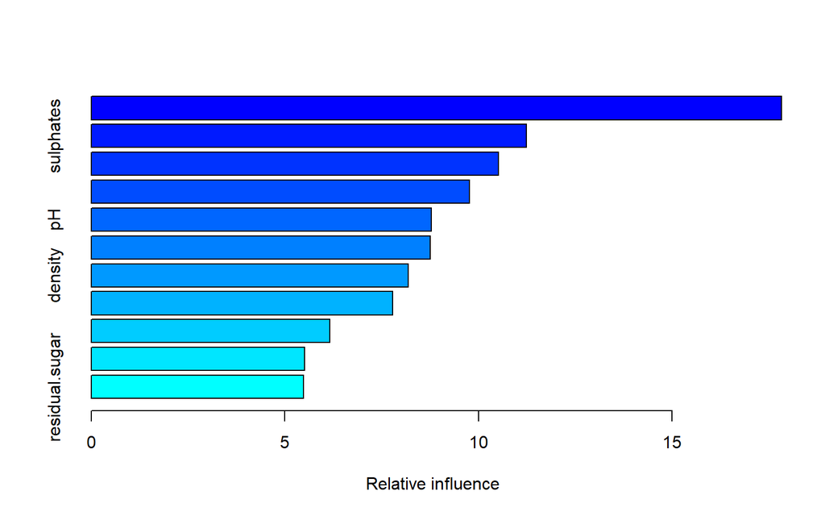

```
                                      var   rel.inf
alcohol                           alcohol 17.820302
sulphates                       sulphates 11.229687
total.sulfur.dioxide total.sulfur.dioxide 10.509681
volatile.acidity         volatile.acidity  9.763079
pH                                     pH  8.778944
chlorides                       chlorides  8.758083
density                           density  8.189132
fixed.acidity               fixed.acidity  7.786563
citric.acid                   citric.acid  6.165689
free.sulfur.dioxide   free.sulfur.dioxide  5.511621
residual.sugar             residual.sugar  5.487219
```

```r
library(gbm)
set.seed(14125)
boosting.model1=gbm((unclass(quality)-1) ~ ., data=train,
                    distribution="bernoulli",
                    n.trees=5000,
                    interaction.depth=4,
                    verbose = F)
summary(boosting.model1)
```

**Modelimizi 5000 agac ile kurduk. Diger modellerde de gordugumuz gibi en onemli degiskenimiz alcohol degiskeni.**

```r
library( e1071)
library(caret)
set.seed(12345)
class.pred=predict(object =boosting.model1, newdata = test, n.trees = 5000, type = "response" )
tahmin=as.factor(ifelse(class.pred>0.5,1,0))
test$quality=as.factor(test$quality)
```

**Test uzerindeki performasimizi hesaplayabiliriz.**

```r
table(tahmin,test$quality)
```

```
tahmin   0   1
     0 125  31
     1  35 129
```

**Tablomuzu olusturduk. Accuracy, Sensitivity ve Specificity oranimizi hesaplamaya gecelim.**

```r
sensitivity(table(tahmin,test$quality))
```

```
[1] 0.78125
```

```r
specificity(table(tahmin,test$quality))
```

```
[1] 0.80625
```

```r
TahminPerf=data.frame(Accuracy=(125+129)/320,Sensitivity=0.78125,Specificity=0.80625)
TahminPerf
```

```
  Accuracy Sensitivity Specificity
1  0.79375     0.78125     0.80625
```

**Olusturdugumuz boosting modelinin performansini test verisi uzerinden hesaplattik. Accuracy degerimiz %79.375 olarak geldi. Artik Lojistik Regresyon yapabiliriz.**

## Logistic Regression

**Yanit degiskenimizin surekli olmadigi durumlarda kullanabilecegimiz ve cok kullanisli olan bir yontem.**

```r
lojistik.model <- glm(quality~ ., data=train, family=binomial)
summary(lojistik.model)
```

```
Call:
glm(formula = quality ~ ., family = binomial, data = train)

Deviance Residuals:
    Min       1Q   Median       3Q      Max
-3.4358  -0.8426   0.3218   0.8111   2.2542

Coefficients:
                       Estimate Std. Error z value Pr(>|z|)
(Intercept)           65.986369  88.733106   0.744   0.4571
fixed.acidity          0.180907   0.111112   1.628   0.1035
volatile.acidity      -3.094321   0.546271  -5.664 1.48e-08 ***
citric.acid           -1.206723   0.628152  -1.921   0.0547 .
residual.sugar         0.018917   0.062721   0.302   0.7629
chlorides             -3.869010   1.719849  -2.250   0.0245 *
free.sulfur.dioxide    0.018333   0.009349   1.961   0.0499 *
total.sulfur.dioxide  -0.015878   0.003194  -4.971 6.67e-07 ***
density              -73.712808  90.600035  -0.814   0.4159
pH                    -0.521305   0.800215  -0.651   0.5148
sulphates              2.482451   0.497641   4.988 6.09e-07 ***
alcohol                0.865303   0.116888   7.403 1.33e-13 ***
---
Signif. codes:  0 '***' 0.001 '**' 0.01 '*' 0.05 '.' 0.1 ' ' 1

(Dispersion parameter for binomial family taken to be 1)

    Null deviance: 1763.4  on 1278  degrees of freedom
Residual deviance: 1323.6  on 1267  degrees of freedom
AIC: 1347.6

Number of Fisher Scoring iterations: 4
```

**Modelimizi kurduk. Model icin anlamli olan degiskenlerimizi goruyoruz. Artik Train-Test verisetlerimizde performansimizi olcmeliyiz.**

```r
set.seed(123)
predictions<-predict(lojistik.model,type="response")
predtrain=ifelse(predictions>0.5,1,0)
```

```r
table(predtrain,train$quality)
```

```
predtrain   0   1
        0 432 165
        1 152 530
```

**Tablomuzu olusturduk. Accuracy, Sensitivity ve Specificity oranimizi hesaplamaya gecelim.**

```r
sensitivity(table(tahmin,test$quality))
```

```
[1] 0.78125
```

```r
specificity(table(tahmin,test$quality))
```

```
[1] 0.80625
```

```r
TahminPerf=data.frame(Accuracy=(432+530)/1279,Sensitivity=0.78125,Specificity=0.80625)
TahminPerf
```

```
   Accuracy Sensitivity Specificity
1 0.7521501     0.78125     0.80625
```

**%75.21 gibi bir dogruluk oranimiz var. Test uzerinden devam edelim.**

```r
set.seed(143)
predicted=predict(lojistik.model,test,type="response")
predtest=ifelse(predicted>0.5,1,0)
```

```r
table(predtest,test$quality)
```

```
predtest   0   1
       0 124  48
       1  36 112
```

**Tablomuzu olusturduk. Accuracy, Sensitivity ve Specificity oranimizi hesaplamaya gecelim.**

```r
sensitivity(table(tahmin,test$quality))
```

```
[1] 0.78125
```

```r
specificity(table(tahmin,test$quality))
```

```
[1] 0.80625
```

```r
TahminPerf=data.frame(Accuracy=(124+112)/320,Sensitivity=0.78125,Specificity=0.80625)
TahminPerf
```

```
  Accuracy Sensitivity Specificity
1   0.7375     0.78125     0.80625
```

**Dogruluk oranimiz %73.75 geldi. İyi bir oran oldugunu soyleyemeyiz. Simdi bazi kriterleri goz onune almamiz ve onları kontrol etmemiz gerekiyor. Multicollinearity, optimum CutOff degelerine bakip degerlendirmemizi yapalim.**

### Multicollinearity

```r
vif(lojistik.model)
```

```
       fixed.acidity     volatile.acidity          citric.acid
            8.044764             1.807484             3.341188
      residual.sugar            chlorides  free.sulfur.dioxide
            1.651653             1.602368             1.952669
total.sulfur.dioxide              density                   pH
            2.154123             5.841003             3.524507
           sulphates              alcohol
            1.505413             2.404957
```

**Coklu baglanti problemi gozukmemektedir.**

### Optimum Cutoff Degeri

**0.5 olarak belirlenen CutOff degerimizi inceleyecegiz.**

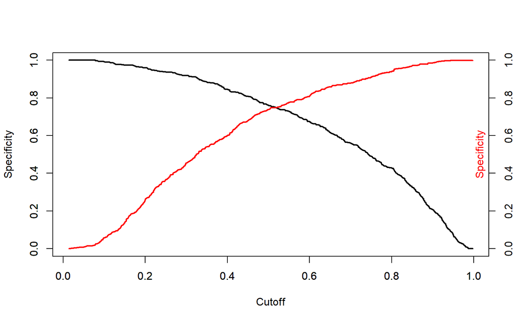

```r
library(ROCR)
predd <- prediction(predictions, train$quality)
plot(unlist(performance(predd, "sens")@x.values), unlist(performance(predd, "sens")@y.values),
     type="l", lwd=2, ylab="Specificity", xlab="Cutoff")
par(new=TRUE)
plot(unlist(performance(predd, "spec")@x.values), unlist(performance(predd, "spec")@y.values),
     type="l", lwd=2, col='red', ylab="", xlab="")
axis(4, at=seq(0,1,0.2))
mtext("Specificity",side=4, padj=-2, col='red')
```

**Gorulen o ki cikan deger 0.5 ten oldukca az farkli. Yani modelimizi etkileyecek kadar degisim gostermedi.**

### ROC

**ROC egrisinin altinda kalan alan ne kadar buyuk ve 1’e yakinsa modelimiz o kadar iyidir diyebiliriz.**

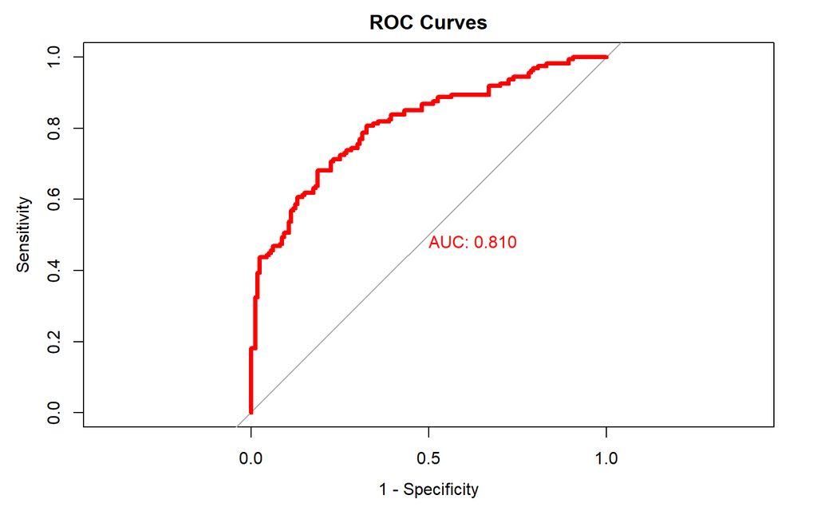

**AUC degeri 0.81 cikti. Modelimizin iyi oldugunu soyleyebiliriz.**

# Model Secimi

**Kurdugumuz tum modellerin performanslarini karsilastirip karar verelim.**

[output not shown]

**Tabloya bakinca en yuksek Accuracy degerinin Bagging(100 Boostrap Sample) modelinde oldugunu goruyoruz. Hem 500 agac sayisini 100 e cekip hiz kazandik hem de is yukunden kurtulmus olduk. Bu yuzden en dogru secim o olacaktir.**

# SORU 2

**Kaynak** http://faculty.marshall.usc.edu/gareth-james/ISL/data.html

**Aciklama** Kisilerin geliri , kredi borcu , limit ve bazi faktorel ozelliklerini iceren veriseti.

**Degiskenler**

**Income** Kisinin geliri

**Limit** Kredi karti limiti

**Rating** Reyting puani

**Cards** Kart sayisi

**Age** Yas

**Education** Egitim

**Gender** Cinsiyet

**Student** Ogrencilik durumu

**Married** Evlilik durumu

**Ethnicity** Koken

**Balance** Borc

```r
credit = read.csv("C:/Users/gizem/OneDrive/Masaüstü/Credit (1).csv")
```

```r
apply(credit,2,function(x) sum(is.na(x)))
```

```
        X    Income     Limit    Rating     Cards       Age Education    Gender
        0         0         0         0         0         0         0         0
  Student   Married Ethnicity   Balance
        0         0         0         0
```

```r
credit<-credit[,-1]
credit$Student<-as.factor(credit$Student)
credit$Married<-as.factor(credit$Married)
credit$Cards<-as.factor(credit$Cards)
credit$Gender<-as.factor(credit$Gender)
credit$Ethnicity<-as.factor(credit$Ethnicity)
summary(credit)
```

```
     Income           Limit           Rating          Cards          Age
 Min.   : 10.35   Min.   :  855   Min.   : 93.0   2      :115   Min.   :23.00
 1st Qu.: 21.01   1st Qu.: 3088   1st Qu.:247.2   3      :111   1st Qu.:41.75
 Median : 33.12   Median : 4622   Median :344.0   4      : 72   Median :56.00
 Mean   : 45.22   Mean   : 4736   Mean   :354.9   1      : 51   Mean   :55.67
 3rd Qu.: 57.47   3rd Qu.: 5873   3rd Qu.:437.2   5      : 34   3rd Qu.:70.00
 Max.   :186.63   Max.   :13913   Max.   :982.0   6      : 11   Max.   :98.00
   Education        Gender    Student   Married              Ethnicity
 Min.   : 5.00   Female:207   No :360   No :155   African American: 99
 1st Qu.:11.00   Male  :193   Yes: 40   Yes:245   Asian           :102
 Median :14.00                                    Caucasian       :199
 Mean   :13.45
 3rd Qu.:16.00
 Max.   :20.00
    Balance
 Min.   :   0.00
 1st Qu.:  68.75
 Median : 459.50
 Mean   : 520.01
 3rd Qu.: 863.00
 Max.   :1999.00
 [ reached getOption("max.print") -- omitted 1 row ]
```

**Verimizi cektik. Ardindan eksik gozlem kontrolu yapip degiskenler ile ilgili islemleri uyguladik.**

```r
head(credit)
```

```
   Income Limit Rating Cards Age Education Gender Student Married Ethnicity
1  14.891  3606    283     2  34        11   Male      No     Yes Caucasian
2 106.025  6645    483     3  82        15 Female     Yes     Yes     Asian
3 104.593  7075    514     4  71        11   Male      No      No     Asian
4 148.924  9504    681     3  36        11 Female      No      No     Asian
5  55.882  4897    357     2  68        16   Male      No     Yes Caucasian
6  80.180  8047    569     4  77        10   Male      No      No Caucasian
  Balance
1     333
2     903
3     580
4     964
5     331
6    1151
```

**Test ve Train ayrimini yapalim.**

```r
set.seed(101)
train=sample(1:nrow(credit),300)
test=credit[-train,"Income"]
```

**Verinin 300 gozlemini Train veriseti icin kullanacagim. Kalan 100 gozlem ise Test verisetini olusturacak.**

## Bagging

```r
set.seed(101)
bag.credit=randomForest(Income~.,data=credit,subset=train,mtry=11,importance=TRUE)
bag.credit
```

```
Call:
 randomForest(formula = Income ~ ., data = credit, mtry = 11,      importance = TRUE, subset = train)
               Type of random forest: regression
                     Number of trees: 500
No. of variables tried at each split: 10

          Mean of squared residuals: 148.4067
                    % Var explained: 87.74
```

**Bagging modelimizi kurduk. 500 agac ve 10 degisken kullanildi. MSE degerimiz 148.4 cikti. Aciklanan varyans degerimiz ise %87.74 cikti. Grafiksel olarak gorelim.**

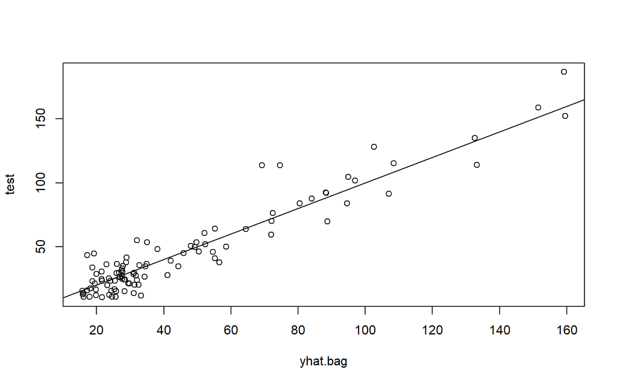

```r
yhat.bag = predict(bag.credit,newdata=credit[-train,])
plot(yhat.bag,test)
abline(0,1)
```

**Tahmin performansimiza bakinca iyi oldugunu soyleyebiliriz.**

```r
mean((yhat.bag-test)^2)
```

```
[1] 137.2665
```

**Test verisi uzerindeki mse degerini goruyoeuz ama out of bag errorleri uzerinden hesaplanan deger degil.**

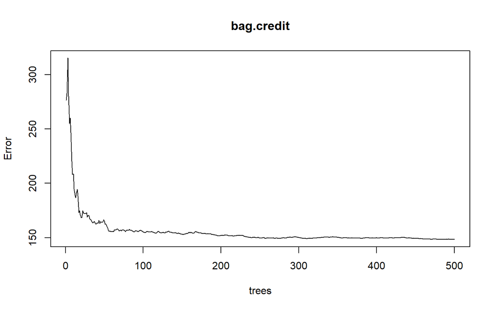

```r
plot(bag.credit)
```

**500 bootstrap sample yerine daha dusuk bir deger secmemiz uygun olacaktir. Goruldugu gibi**

```r
head(bag.credit$mse,250)
```

```
 [1] 276.2965 282.6717 315.2195 280.2074 255.0257 260.1343 246.6736 220.2070
 [9] 208.1831 208.6727 194.7121 189.1803 186.7573 190.5382 194.4962 188.1083
[17] 173.1497 174.8614 171.3740 168.1799 168.2793 174.7943 172.8839 172.2940
[25] 172.2797 172.1077 173.0741 168.9544 170.5005 170.4576 167.8757 166.6563
[33] 166.1720 164.7983 163.4271 164.0295 164.9432 163.5374 162.5114 163.3869
[41] 163.4557 163.4229 165.9015 162.9751 164.7899 164.2488 164.3049 164.5255
[49] 166.6796 165.3524 162.4925 162.4959 160.9407 159.1230 157.1580 155.8041
[57] 156.1892 155.6378 155.5104 155.4728 155.9624 155.5186 157.3361 157.1078
[65] 157.3307 157.9623 157.8998 157.4538 156.2910 156.7238 156.6667 156.1512
[73] 157.3305 156.9958 157.0999
 [ reached getOption("max.print") -- omitted 175 entries ]
```

**Simdi 500 ağaçlı model yerine 50 ağaçlı model kurarsak ne olur inceleyelim.**

```r
set.seed(897)
bag.credit=randomForest(Income~.,data=credit,subset=train,mtry=11,ntree=50)
yhat.bag = predict(bag.credit,newdata=credit[-train,])
mean((yhat.bag-test)^2)
```

```
[1] 138.8545
```

**50 ağaçlada yaklasik olarak ayni sonucu elde ettik. Hata degerimizde ufak bir artis olsa da is yukumuzu azaltmis olmamiz bu modeli kullanmak daha mantikli olur. Simdi Random Forest yapalim.**

## Random Forest

**Random Forest mtry=4 alip modelimizi kuracagiz.**

```r
set.seed(101)
rf.credit=randomForest(Income~.,data=credit,subset=train,mtry=4,importance=TRUE)
yhat.rf = predict(rf.credit,newdata=credit[-train,])
mean((yhat.rf-test)^2)
```

```
[1] 164.513
```

**Goruyoruz ki test verisi uzerinde hesaplanan MSE degeri artti. Farkli mtray degerlerine bakmak icin OOB MSE degerleri ile test verisi MSE degerlerini karsilastiralim.**

```r
oob.err<-double(11)
test.err<-double(11)

#mtry is no of Variables randomly chosen at each split
for(mtry in 1:11)
{
  rf=randomForest(Income ~ . , data = credit , subset = train,mtry=mtry,ntree=500)
  oob.err[mtry] = rf$mse[500] #Error of all Trees fitted

  pred<-predict(rf,credit[-train,]) #Predictions on Test Set for each Tree
  test.err[mtry]= with(credit[-train,], mean( (Income - pred)^2)) #Mean Squared Test Error

  cat(mtry," ")

}
```

```
1  2  3  4  5  6  7  8  9  10  11
```

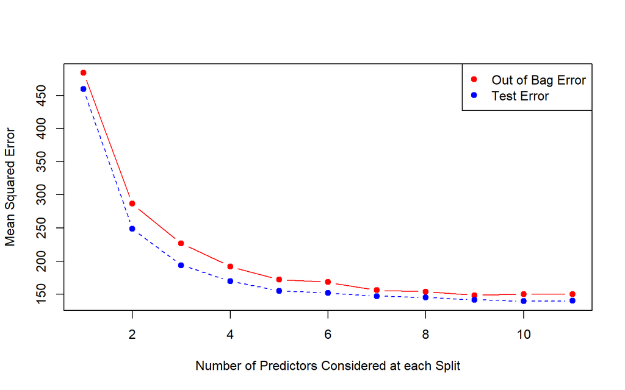

```r
set.seed(322)
matplot(1:mtry , cbind(oob.err,test.err), pch=19 , col=c("red","blue"),type="b",ylab="Mean Squared Error",xlab="Number of Predictors Considered at each Split")
legend("topright",legend=c("Out of Bag Error","Test Error"),pch=19, col=c("red","blue"))
```

```r
set.seed(34)
test.err[5]
```

```
[1] 155.2665
```

**mtry=5 ile error degerimiz dustu.**

```r
importance(rf.credit)
```

```
             %IncMSE IncNodePurity
Limit     34.1940322    138276.337
Rating    32.8119661    130936.410
Cards      1.0605404      9127.368
Age        5.6389922     16104.730
Education -2.2322635      7507.913
Gender    -1.3275926      1382.501
Student    1.8781834      1432.841
Married    0.3054671      1491.477
Ethnicity -1.5200971      3207.380
Balance   51.6819476     47148.766
```

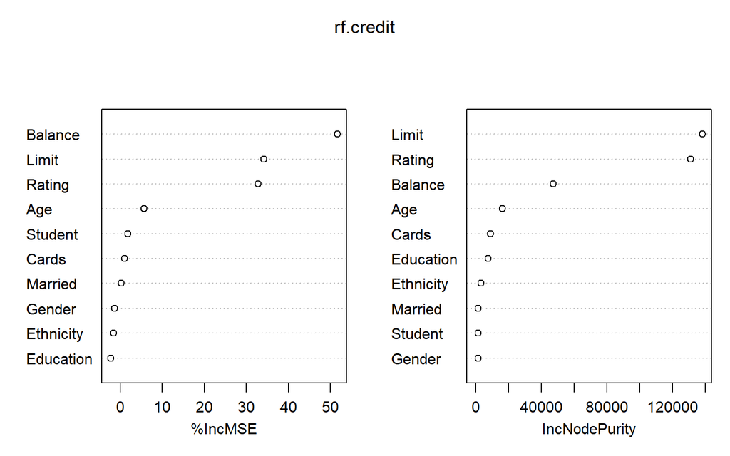

```r
varImpPlot(rf.credit)
```

**Olcutlere gore degiskenlerin onem derecesine baktigimizde Rating , Limit ve Balance degiskenlerinin oldukca onemli oldugunu goruyoruz.**

## Boosting

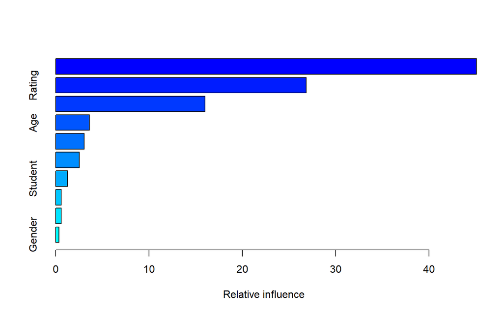

```
                var    rel.inf
Limit         Limit 45.0819781
Rating       Rating 26.8505255
Balance     Balance 16.0161322
Age             Age  3.6332387
Cards         Cards  3.0489531
Education Education  2.5435287
Student     Student  1.2655962
Married     Married  0.6165599
Ethnicity Ethnicity  0.5975654
Gender       Gender  0.3459221
```

```r
set.seed(101)
boost.credit=gbm(Income~.,data=credit[train,],distribution="gaussian",n.trees=5000,interaction.depth=4)
summary(boost.credit)
```

**Summary’e baktigimzda degiskenlerin MSE icin etkisini goruyoruz. Limit degiskenini cikarirsak MSE degeri max artis gosterecektir. Simdi test verisi uzerinden performansimiza bakalim.**

```r
set.seed(4324)
yhat.boost=predict(boost.credit,newdata=credit[-train,],n.trees=5000)
mean((yhat.boost-test)^2)
```

```
[1] 113.6587
```

**MSE degeri diger modellere gore daha iyi geldi.**

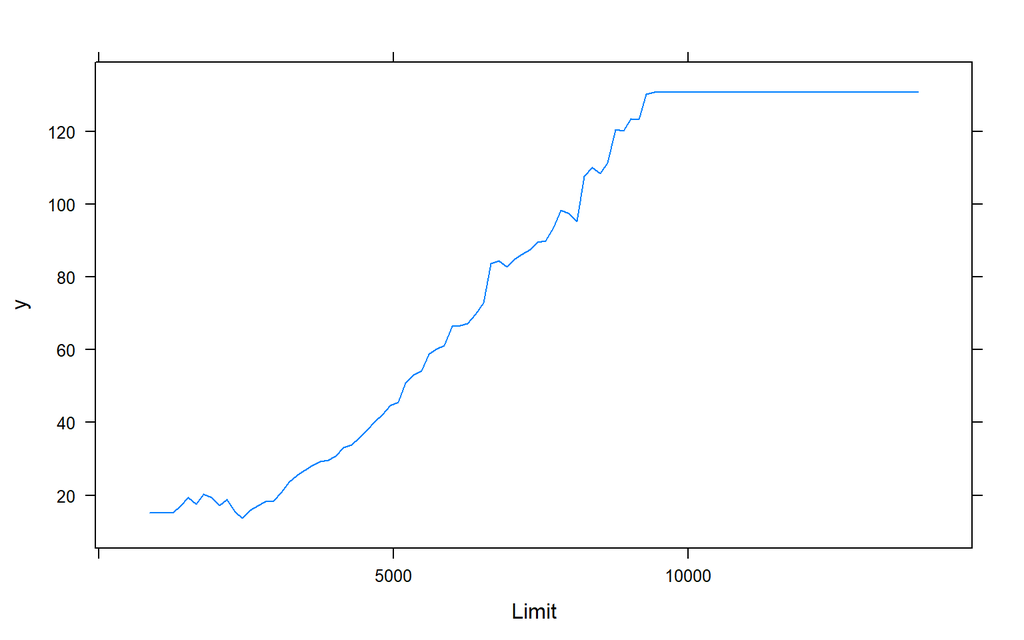

```r
plot(boost.credit,i="Limit")
```

**Limit ile yanıt degiskeni arasindaki iliskiyi gosterir.**

# Model Secimi

[output not shown]

**MSE degerlerine baktigimizda en dusuk degeri veren model Boosting modeli olarak gozukuyor.**

# SORU 3

- **Kaynak:** https://statsandr.com/blog/clustering-analysis-k-means-and-hierarchical-clustering-by-hand-and-in-r/
- **Aciklama** Bu veriseti , 1979’da 26 Avrupa ulkesinde farkli endustrilerde calisan nufusun yuzdesini icermektedir. 10 degisken icermektedir

**Degiskenler**

**Country** ulkenin adi

**Agr** Tarimda istihdam edilen isgucunun yuzdesi

**Min** madencilik

**Man** imalat

**PS** Guc kaynaklari endustrileri

**Con** İnsaat sektoru

**SI** Hizmet sektorleri

**Fin** Finans

**SPS** sosyal ve kisisel hizmetler

**TC** ulasim ve iletisim

```r
Eurojobs <- read.csv(
  file = "https://statsandr.com/blog/data/Eurojobs.csv",
  sep = ",", dec = ".", header = TRUE, row.names = 1
)
```

```r
head(Eurojobs)
```

```
            Agr Min  Man  PS  Con   SI Fin  SPS  TC
Belgium     3.3 0.9 27.6 0.9  8.2 19.1 6.2 26.6 7.2
Denmark     9.2 0.1 21.8 0.6  8.3 14.6 6.5 32.2 7.1
France     10.8 0.8 27.5 0.9  8.9 16.8 6.0 22.6 5.7
W. Germany  6.7 1.3 35.8 0.9  7.3 14.4 5.0 22.3 6.1
Ireland    23.2 1.0 20.7 1.3  7.5 16.8 2.8 20.8 6.1
Italy      15.9 0.6 27.6 0.5 10.0 18.1 1.6 20.1 5.7
```

```r
data_scale=scale(Eurojobs)
```

**Verimize standartlastirma uyguladik.**

## K Means Kumeleme

```r
set.seed(111)
Kume2=kmeans(data_scale, centers = 3)
str(Kume2)
```

```
List of 9
 $ cluster     : Named int [1:26] 1 1 1 1 1 1 1 1 1 1 ...
  ..- attr(*, "names")= chr [1:26] "Belgium" "Denmark" "France" "W. Germany" ...
 $ centers     : num [1:3, 1:9] -0.487 0.353 2.484 -0.455 0.95 ...
  ..- attr(*, "dimnames")=List of 2
  .. ..$ : chr [1:3] "1" "2" "3"
  .. ..$ : chr [1:9] "Agr" "Min" "Man" "PS" ...
 $ totss       : num 225
 $ withinss    : num [1:3] 65.5 39.1 13.4
 $ tot.withinss: num 118
 $ betweenss   : num 107
 $ size        : int [1:3] 16 8 2
 $ iter        : int 3
 $ ifault      : int 0
 - attr(*, "class")= chr "kmeans"
```

**3 kume ile basladik. Kareler toplami ve daha bir cok bilgi iceren bir ozet ile karsilastik. Simdi optimum kume sayisini belirlemek icin Elbow ve Silhoutte methodlarini kullanalim.**

*Elbow Method*

- *Kumeler ici hata hesaplama*

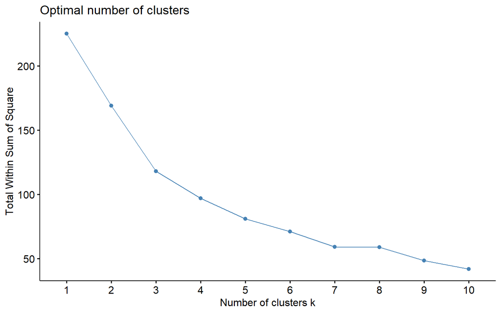

```r
set.seed(138)
fviz_nbclust(data_scale, kmeans, method = "wss")
```

**3 kume olusturmak mantikli duruyor.**

*Average Silhoutte Method*

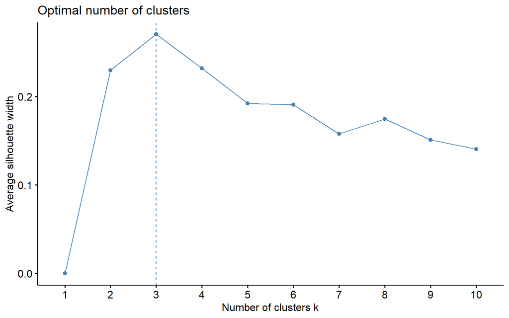

```r
set.seed(321)
fviz_nbclust(data_scale, kmeans, method = "silhouette")
```

**Kumeler icinde kalite skoru hesaplayan bir metod olan Silhoutte 3 kumenin en iyi oldugunu soyluyor.**

```r
set.seed(123)
SON <- kmeans(data_scale, 3)
SON
```

```
K-means clustering with 3 clusters of sizes 2, 8, 16

Cluster means:
         Agr        Min         Man          PS        Con         SI
1  2.4840999 -0.1585972 -2.09163650 -0.81786082 -2.6223997 -1.5644365
2  0.3526007  0.9496004  0.38775681  0.14568146  0.1121882 -0.9524484
3 -0.4868128 -0.4549756  0.06757616  0.02939187  0.2717058  0.6717788
         Fin        SPS          TC
1  0.7838767 -1.6725978 -2.11729825
2 -1.0332921 -0.4097020  0.50582974
3  0.4186614  0.4139257  0.01174741

Clustering vector:
       Belgium        Denmark         France     W. Germany        Ireland
             3              3              3              3              3
         Italy     Luxembourg    Netherlands United Kingdom        Austria
             3              3              3              3              3
       Finland         Greece         Norway       Portugal          Spain
             3              2              3              3              3
        Sweden    Switzerland         Turkey       Bulgaria Czechoslovakia
             3              3              1              2              2
    E. Germany        Hungary         Poland        Rumania           USSR
             2              2              2              2              2
    Yugoslavia
             1

Within cluster sum of squares by cluster:
[1] 13.44198 39.14856 65.48018
 (between_SS / total_SS =  47.5 %)

Available components:

[1] "cluster"      "centers"      "totss"        "withinss"     "tot.withinss"
[6] "betweenss"    "size"         "iter"         "ifault"
```

**Burada hangi gozlemin hangi kumeye gittigini , degiskenlerin kume bazinda ortalamari gibi bilgiler mevcut.**

## Hiyerarsik Kumeleme

```r
set.seed(213)
m <- c( "average", "single", "complete", "ward")
names(m) <- c( "average", "single", "complete", "ward")
ac <- function(x) {
agnes(dist(data_scale,method="euclidean"), method = x)$ac
}
map_dbl(m, ac)
```

```
  average    single  complete      ward
0.6587886 0.5845058 0.7365102 0.7908569
```

**En yuksek degeri veren linkage metodunu bulduk. Sonuca bakildiginda en yuksek degeri ward yontemi verdi.**

```r
set.seed(345)
hc<-hclust(dist(data_scale,method="euclidean"),method="ward.D2")
hc
```

```
Call:
hclust(d = dist(data_scale, method = "euclidean"), method = "ward.D2")

Cluster method   : ward.D2
Distance         : euclidean
Number of objects: 26
```

**K means’te kullandigimiz yontemleri kullanalim.**

*Elbow Method*

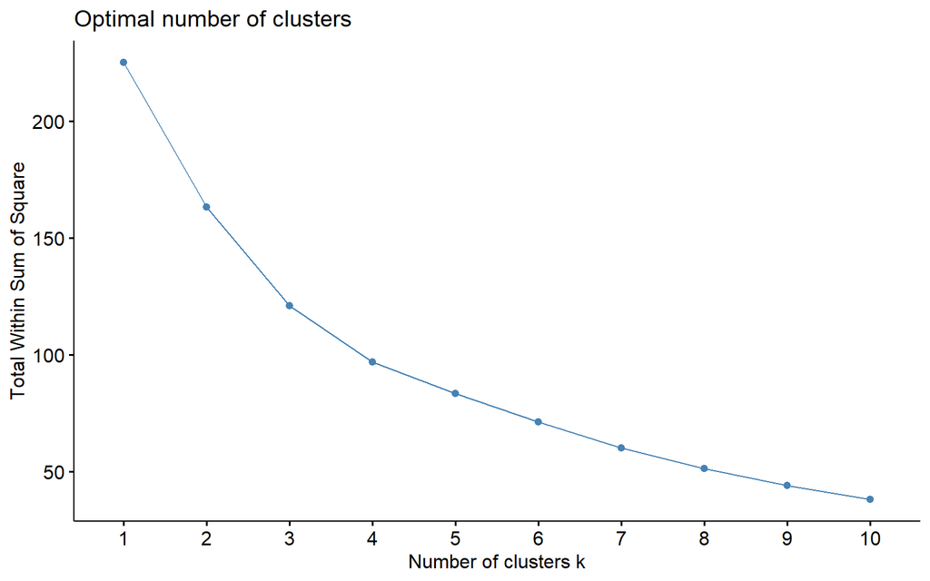

```r
fviz_nbclust(data_scale, FUN = hcut, method = "wss")
```

**3 kume secimi dogru olacak gibi duruyor ancak kesin karar veremiyoruz. Silhoutte methoduyla daha net bir sonuc cikarabiliriz.**

*Average Silhouette Method*

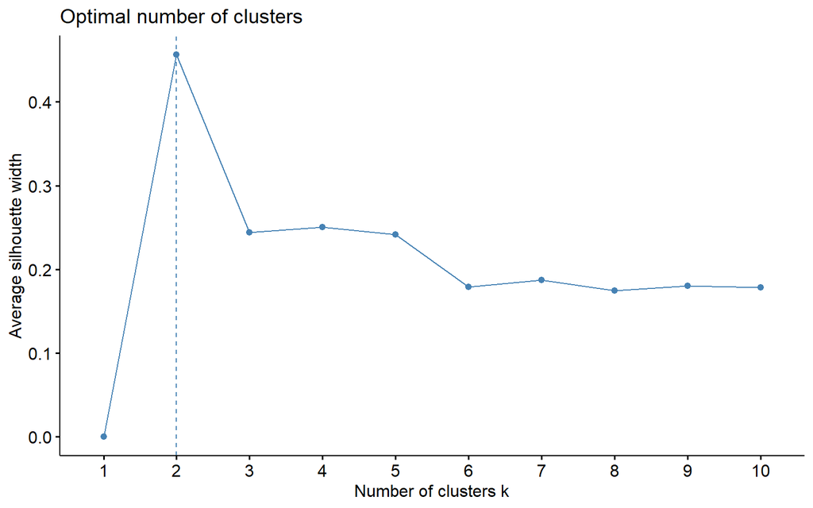

```r
fviz_nbclust(data_scale, FUN = hcut, method = "silhouette")
```

**2 kume secimi en iyi degeri verdi.**

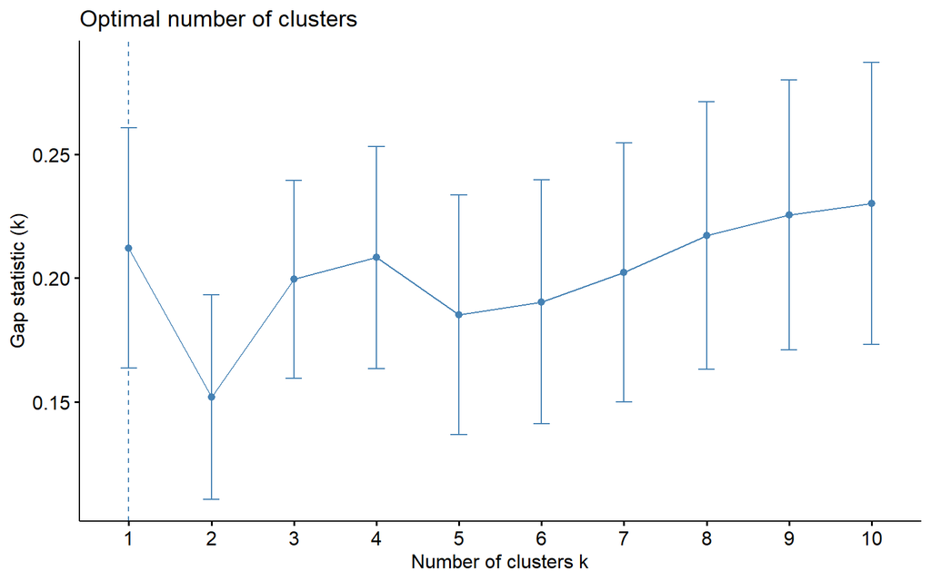

```r
set.seed(788)
gap_stat <- clusGap(data_scale, FUN = hcut, nstart = 25, K.max = 10, B = 50)
fviz_gap_stat(gap_stat)
```

**GAP methodu sonucu 1 olarak verdi. Ancak biz 2 ve 3 u kullanacagiz.**

**Her method farkli sonuclar verdi. Burada yapilmasi gereken ilgilenilen veri uzerinde bilgi sahibi olmak ve tecrube ile karar vermek. En dogru secimi bu sekilde yaparak yola devam etmek gerekiyor.**

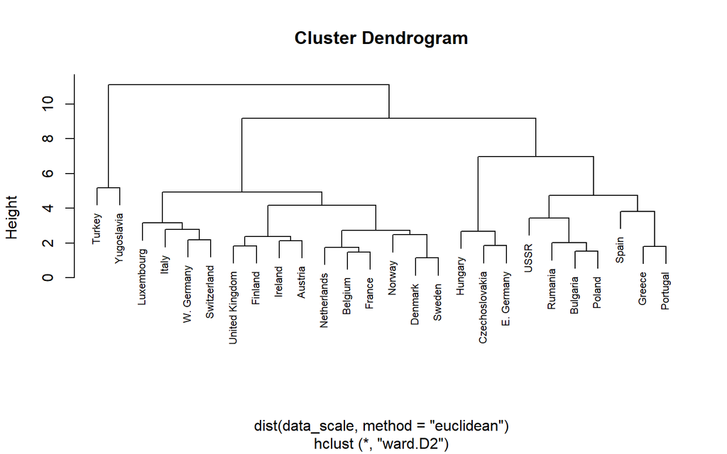

```r
hc2<-hclust(dist(data_scale,method="euclidean"),method="ward.D2")
plot(hc2,cex=0.7)
```

**Dendogramimizi olusturduk. 3 noktadan kesim yapip gorselimizi gorelim.**

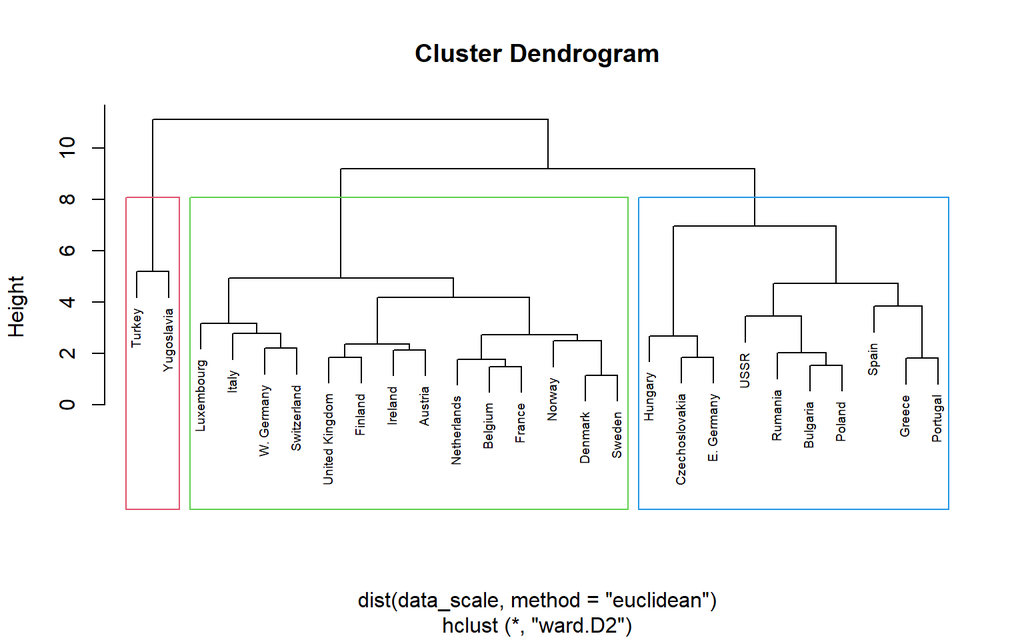

```r
plot(hc2, cex = 0.6)
rect.hclust(hc2, k = 3, border = 2:9)
```

**Olusturdugumuz dendogram oldukca anlasilir bir halde gozukuyor. Incelenmesi karisik olmayacaktir.**

```r
sub_grp <- cutree(hc, k = 3)
```

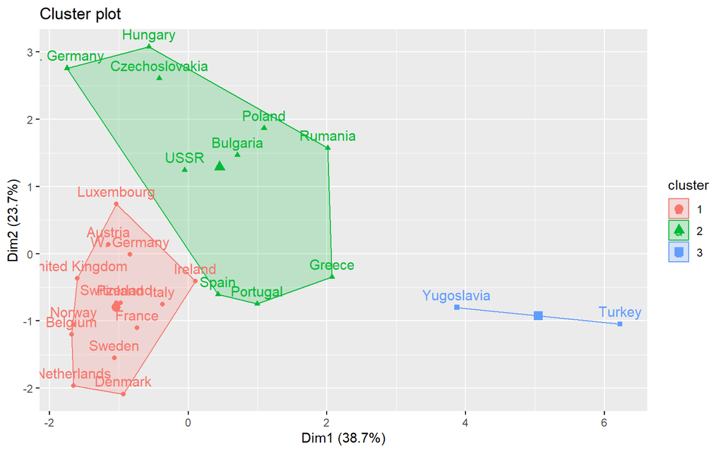

```r
library(factoextra)
fviz_cluster(list(data = data_scale, cluster = sub_grp))
```